# Homework 1

Robert Rose

```python
import pandas as pd
import numpy as np
import seaborn as sns
import matplotlib.pyplot as plt
import warnings
warnings.simplefilter("ignore")
```

```python
df = pd.read_csv("./Parking_Citations.csv")
```

The [Open Baltimore website](https://data.baltimorecity.gov/Transportation/Parking-Citations/n4ma-fj3m) says that this dataset contains information on parking citations issued within the City. Data represents years of citations and any older citations with outstanding balances. It is updated every weekday automatically by the Finance Department.

```python
df.head(50)
```

|  | Citation | Tag | ExpMM | ExpYY | State | Make | Address | ViolCode | Description | ViolFine | ... | Balance | PenaltyDate | OpenFine | OpenPenalty | NoticeDate | ImportDate | Neighborhood | PoliceDistrict | CouncilDistrict | Location |
| --- | --- | --- | --- | --- | --- | --- | --- | --- | --- | --- | --- | --- | --- | --- | --- | --- | --- | --- | --- | --- | --- |
| 0 | 82691651 | 69943CF | 04 | 19.0 | MD | MAZD | 1300 BLK EAST NORTHERN PKWY WB | 32 | Fixed Speed Camera | 40.0 | ... | 0.0 | NaN | 0.0 | 0.0 | NaN | 04/26/2018 04:02:00 AM | NaN | NaN | NaN | 1300 BLK EAST NORTHERN PKWY\nWB Baltimore, MD\... |
| 1 | 85937226 | T720887 | 12 | 18.0 | MD | ACUR | 300 BLK NORTH BEND RD SB | 32 | Fixed Speed Camera | 40.0 | ... | 40.0 | NaN | 0.0 | 0.0 | NaN | 01/03/2019 04:33:00 AM | NaN | NaN | NaN | NaN |
| 2 | 82691115 | 5BA2678 | 03 | 19.0 | MD | TOYT | 5000 BLK ROLAND AVE NB | 32 | Fixed Speed Camera | 40.0 | ... | 0.0 | NaN | 0.0 | 0.0 | NaN | 04/26/2018 04:02:00 AM | NaN | NaN | NaN | 5000 BLK ROLAND AVE\nNB Baltimore, MD\n(39.353... |
| 3 | 82694689 | 5BT8544 | 01 | 18.0 | MD | FORD | 2400 BLK ERDMAN AVE NB | 32 | Fixed Speed Camera | 40.0 | ... | 0.0 | NaN | 0.0 | 0.0 | NaN | 04/26/2018 04:02:00 AM | NaN | NaN | NaN | 2400 BLK ERDMAN AVE\nNB Baltimore, MD\n(39.325... |
| 4 | 82691214 | 1BV0537 | 11 | 18.0 | MD | SUBA | 1300 BLK WEST COLD SPRING LN W | 32 | Fixed Speed Camera | 40.0 | ... | 0.0 | NaN | 0.0 | 0.0 | NaN | 04/26/2018 04:02:00 AM | NaN | NaN | NaN | 1300 BLK WEST COLD SPRING LN W\nBaltimore, MD\... |
| 5 | 82688467 | 5CZ9237 | 08 | 19.0 | MD | NISS | 3400 BLKLOCH RAVEN BLVD NB | 32 | Fixed Speed Camera | 40.0 | ... | 0.0 | NaN | 0.0 | 0.0 | NaN | 04/26/2018 04:02:00 AM | NaN | NaN | NaN | 3400 BLKLOCH RAVEN BLVD\nNB Baltimore, MD\n(39... |
| 6 | 82690141 | MCG966 | 12 | 19.0 | MD | HOND | 6100 BLK OLD HARFORD RD NB | 32 | Fixed Speed Camera | 40.0 | ... | 0.0 | NaN | 0.0 | 0.0 | NaN | 04/26/2018 04:02:00 AM | NaN | NaN | NaN | 6100 BLK OLD HARFORD RD\nNB Baltimore, MD\n(39... |
| 7 | 82688442 | 9DE2544 | 03 | 20.0 | MD | NISS | 4300 BLK ERDMAN AVE NB | 32 | Fixed Speed Camera | 40.0 | ... | 40.0 | NaN | 0.0 | 0.0 | NaN | 04/26/2018 04:02:00 AM | NaN | NaN | NaN | 4300 BLK ERDMAN AVE\nNB Baltimore, MD\n(39.311... |
| 8 | 82693525 | 7DA8010 | 10 | 19.0 | MD | HYUN | 5600 BLK MORAVIA RD NB | 32 | Fixed Speed Camera | 40.0 | ... | 40.0 | NaN | 0.0 | 0.0 | NaN | 04/26/2018 04:02:00 AM | NaN | NaN | NaN | 5600 BLK MORAVIA RD\nNB Baltimore, MD\n(39.320... |
| 9 | 82687725 | 4DA3646 | 08 | 19.0 | MD | JEEP | 4300 BLK ERDMAN AVE NB | 32 | Fixed Speed Camera | 40.0 | ... | 40.0 | NaN | 0.0 | 0.0 | NaN | 04/26/2018 04:02:00 AM | NaN | NaN | NaN | 4300 BLK ERDMAN AVE\nNB Baltimore, MD\n(39.311... |
| 10 | 82689150 | 6DCX96 | 10 | 19.0 | MD | TOYT | 2700 BLK GWYNNS FALLS PKY WB | 32 | Fixed Speed Camera | 40.0 | ... | 0.0 | NaN | 0.0 | 0.0 | NaN | 04/26/2018 04:02:00 AM | NaN | NaN | NaN | 2700 BLK GWYNNS FALLS PKY\nWB Baltimore, MD\n(... |
| 11 | 82692832 | 5AP5656 | 02 | 20.0 | MD | TOYT | 1200 BLK SOUTH CATON AVE NB | 32 | Fixed Speed Camera | 40.0 | ... | 0.0 | NaN | 0.0 | 0.0 | NaN | 04/26/2018 04:02:00 AM | NaN | NaN | NaN | 1200 BLK SOUTH CATON AVE\nNB Baltimore, MD\n(3... |
| 12 | 82697393 | 89508CF | 07 | 18.0 | MD | TOYT | 2400 BLK ERDMAN AVE NB | 32 | Fixed Speed Camera | 40.0 | ... | 0.0 | NaN | 0.0 | 0.0 | NaN | 04/26/2018 04:02:00 AM | NaN | NaN | NaN | 2400 BLK ERDMAN AVE\nNB Baltimore, MD\n(39.325... |
| 13 | 85937242 | 5DB4425 | 09 | 19.0 | MD | CHEV | 2800 BLK REISTERSTOWN RD WB | 32 | Fixed Speed Camera | 40.0 | ... | 40.0 | NaN | 0.0 | 0.0 | NaN | 01/03/2019 04:33:00 AM | NaN | NaN | NaN | NaN |
| 14 | 85937259 | 38270CH | 03 | 18.0 | MD | HOND | 2800 BLK REISTERSTOWN RD EB | 32 | Fixed Speed Camera | 40.0 | ... | 40.0 | NaN | 0.0 | 0.0 | NaN | 01/03/2019 04:33:00 AM | NaN | NaN | NaN | NaN |
| 15 | 82689739 | 7DE9147 | 03 | 20.0 | MD | NISS | 2400 BLK ERDMAN AVE NB | 32 | Fixed Speed Camera | 40.0 | ... | 0.0 | NaN | 0.0 | 0.0 | NaN | 04/26/2018 04:02:00 AM | NaN | NaN | NaN | 2400 BLK ERDMAN AVE\nNB Baltimore, MD\n(39.325... |
| 16 | 82685372 | 2AN3165 | 07 | 18.0 | MD | CHEV | 1200 BLK SOUTH CATON AVE NB | 32 | Fixed Speed Camera | 40.0 | ... | 0.0 | NaN | 0.0 | 0.0 | NaN | 04/26/2018 04:02:00 AM | NaN | NaN | NaN | 1200 BLK SOUTH CATON AVE\nNB Baltimore, MD\n(3... |
| 17 | 82692360 | BRT002 | 05 | 18.0 | MI | TOYOT | 2400 BLK ERDMAN AVE NB | 32 | Fixed Speed Camera | 40.0 | ... | 0.0 | NaN | 0.0 | 0.0 | NaN | 04/26/2018 04:02:00 AM | NaN | NaN | NaN | 2400 BLK ERDMAN AVE\nNB Baltimore, MD\n(39.325... |
| 18 | 1537 | 7AD3147 | 01 | 13.0 | MD | CHRY | UB S EUTAW | 12 | No Stopping/Standing Not Tow-Away Zone | 32.0 | ... | 332.0 | NaN | 32.0 | 300.0 | 01/04/2012 | 08/09/2013 04:03:00 AM | NaN | NaN | NaN | UB S EUTAW Baltimore, MD |
| 19 | 82696254 | KHY369 | 03 | 19.0 | MD | HOND | 4401 PENNINGTON AVE SB | 32 | Fixed Speed Camera | 40.0 | ... | 0.0 | NaN | 0.0 | 0.0 | NaN | 04/26/2018 04:02:00 AM | NaN | NaN | NaN | 4401 PENNINGTON AVE\nSB Baltimore, MD\n(39.226... |
| 20 | 82694135 | 28758M6 | 02 | 19.0 | MD | KIA | 2400 BLK ERDMAN AVE NB | 32 | Fixed Speed Camera | 40.0 | ... | 0.0 | NaN | 0.0 | 0.0 | NaN | 04/26/2018 04:02:00 AM | NaN | NaN | NaN | 2400 BLK ERDMAN AVE\nNB Baltimore, MD\n(39.325... |
| 21 | 82694655 | 3DE2314 | 02 | 20.0 | MD | MAZD | 1300 BLK WEST COLD SPRING LN E | 32 | Fixed Speed Camera | 40.0 | ... | 0.0 | NaN | 0.0 | 0.0 | NaN | 04/26/2018 04:02:00 AM | NaN | NaN | NaN | 1300 BLK WEST COLD SPRING LN E\nBaltimore, MD\... |
| 22 | 82696510 | 097M578 | 07 | 19.0 | MD | HOND | 4400 BLK EDMONDSON AVE WB | 32 | Fixed Speed Camera | 40.0 | ... | 0.0 | NaN | 0.0 | 0.0 | NaN | 04/26/2018 04:02:00 AM | NaN | NaN | NaN | 4400 BLK EDMONDSON AVE\nWB Baltimore, MD\n(39.... |
| 23 | 82692410 | PP9H4L | 08 | 18.0 | MO | HYUN | 5000 BLK ROLAND AVE NB | 32 | Fixed Speed Camera | 40.0 | ... | 40.0 | NaN | 0.0 | 0.0 | NaN | 04/26/2018 04:02:00 AM | NaN | NaN | NaN | 5000 BLK ROLAND AVE\nNB Baltimore, MD\n(39.353... |
| 24 | 82688392 | BKT4450 | 04 | 19.0 | NC | BMW | 5900 BLK WALTHER AVE NB | 32 | Fixed Speed Camera | 40.0 | ... | 0.0 | NaN | 0.0 | 0.0 | NaN | 04/26/2018 04:02:00 AM | NaN | NaN | NaN | 5900 BLK WALTHER AVE\nNB Baltimore, MD\n(39.34... |
| 25 | 82688582 | 55622CG | 06 | 19.0 | MD | HYUN | 1300 BLK EAST NORTHERN PKWY WB | 32 | Fixed Speed Camera | 40.0 | ... | 40.0 | NaN | 0.0 | 0.0 | NaN | 04/26/2018 04:02:00 AM | NaN | NaN | NaN | 1300 BLK EAST NORTHERN PKWY\nWB Baltimore, MD\... |
| 26 | 82692584 | 43688CG | 10 | 18.0 | MD | LEXS | 4300 BLK ERDMAN AVE NB | 32 | Fixed Speed Camera | 40.0 | ... | 0.0 | NaN | 0.0 | 0.0 | NaN | 04/26/2018 04:02:00 AM | NaN | NaN | NaN | 4300 BLK ERDMAN AVE\nNB Baltimore, MD\n(39.311... |
| 27 | 82692147 | 8CW5981 | 04 | 19.0 | MD | DODG | 1200 BLK SOUTH CATON AVE NB | 32 | Fixed Speed Camera | 40.0 | ... | 40.0 | NaN | 0.0 | 0.0 | NaN | 04/26/2018 04:02:00 AM | NaN | NaN | NaN | 1200 BLK SOUTH CATON AVE\nNB Baltimore, MD\n(3... |
| 28 | 82696536 | 6CM0625 | 09 | 18.0 | MD | DODG | 1300 BLK EAST NORTHERN PKWY WB | 32 | Fixed Speed Camera | 40.0 | ... | 0.0 | NaN | 0.0 | 0.0 | NaN | 04/26/2018 04:02:00 AM | NaN | NaN | NaN | 1300 BLK EAST NORTHERN PKWY\nWB Baltimore, MD\... |
| 29 | 82691073 | 50956CD | 05 | 18.0 | MD | HOND | 600 BLK W NORTHERN PKWY EB | 32 | Fixed Speed Camera | 40.0 | ... | 0.0 | NaN | 0.0 | 0.0 | NaN | 04/26/2018 04:02:00 AM | NaN | NaN | NaN | 600 BLK W NORTHERN PKWY\nEB Baltimore, MD\n(39... |
| 30 | 85937275 | 2BE2371 | 12 | 19.0 | MD | NISS | 600 BLK W NORTHERN PKWY EB | 32 | Fixed Speed Camera | 40.0 | ... | 40.0 | NaN | 0.0 | 0.0 | NaN | 01/03/2019 04:33:00 AM | NaN | NaN | NaN | NaN |
| 31 | 2485 | 244084 | 03 | 12.0 | DE | BMW | 4000 E SARATOGA ST | 18 | All Other Parking Meter Violations | 32.0 | ... | 332.0 | NaN | 32.0 | 300.0 | 04/27/2012 | 11/09/2013 04:04:00 AM | NaN | NaN | NaN | 4000 E SARATOGA ST\nBaltimore, MD |
| 32 | 2527 | 8FHL65 | 05 | 12.0 | MD | ACURA | UB S CALVERT ST | 18 | All Other Parking Meter Violations | 32.0 | ... | 0.0 | NaN | 32.0 | 300.0 | 01/04/2012 | 08/09/2013 04:03:00 AM | NaN | NaN | NaN | UB S CALVERT ST Baltimore, MD |
| 33 | 2568 | 5AJ4941 | 08 | 13.0 | MD | BUIC | UB SOUTH ST | 20 | Passenger Loading Zone | 32.0 | ... | 332.0 | NaN | 32.0 | 300.0 | 01/18/2012 | 08/09/2013 04:03:00 AM | NaN | NaN | NaN | UB SOUTH ST Baltimore, MD |
| 34 | 2600 | 3AM1741 | 01 | 12.0 | MD | FORD | UB E REDWOOD ST | 18 | All Other Parking Meter Violations | 32.0 | ... | 332.0 | NaN | 32.0 | 300.0 | 01/18/2012 | 08/09/2013 04:03:00 AM | NaN | NaN | NaN | UB E REDWOOD ST Baltimore, MD |
| 35 | 82694119 | 2CZ4377 | 07 | 19.0 | MD | HOND | 4300 BLK ERDMAN AVE SB | 32 | Fixed Speed Camera | 40.0 | ... | 0.0 | NaN | 0.0 | 0.0 | NaN | 04/26/2018 04:02:00 AM | NaN | NaN | NaN | 4300 BLK ERDMAN AVE\nSB Baltimore, MD\n(39.311... |
| 36 | 82689804 | 2CT3000 | 12 | 18.0 | MD | HOND | 1300 BLK WEST COLD SPRING LN W | 32 | Fixed Speed Camera | 40.0 | ... | 0.0 | NaN | 0.0 | 0.0 | NaN | 04/26/2018 04:02:00 AM | NaN | NaN | NaN | 1300 BLK WEST COLD SPRING LN W\nBaltimore, MD\... |
| 37 | 82690026 | UB00069 | 01 | 19.0 | MD | RAM | 5000 BLK ROLAND AVE NB | 32 | Fixed Speed Camera | 40.0 | ... | 0.0 | NaN | 0.0 | 0.0 | NaN | 04/26/2018 04:02:00 AM | NaN | NaN | NaN | 5000 BLK ROLAND AVE\nNB Baltimore, MD\n(39.353... |
| 38 | 82693038 | 3BT0398 | 07 | 18.0 | MD | KIA | 2400 BLK ERDMAN AVE NB | 32 | Fixed Speed Camera | 40.0 | ... | 0.0 | NaN | 0.0 | 0.0 | NaN | 04/26/2018 04:02:00 AM | NaN | NaN | NaN | 2400 BLK ERDMAN AVE\nNB Baltimore, MD\n(39.325... |
| 39 | 85937291 | 2CV2541 | 03 | 19.0 | MD | HYUN | 3900 BLK THE ALAMEDA WB | 32 | Fixed Speed Camera | 40.0 | ... | 40.0 | NaN | 0.0 | 0.0 | NaN | 01/03/2019 04:33:00 AM | NaN | NaN | NaN | NaN |
| 40 | 82692519 | 8DB0804 | 11 | 19.0 | MD | TOYT | 2400 BLK ERDMAN AVE NB | 32 | Fixed Speed Camera | 40.0 | ... | 0.0 | NaN | 0.0 | 0.0 | NaN | 04/26/2018 04:02:00 AM | NaN | NaN | NaN | 2400 BLK ERDMAN AVE\nNB Baltimore, MD\n(39.325... |
| 41 | 82687923 | 2EST11 | 12 | 19.0 | MD | BMW | 2400 BLK ERDMAN AVE NB | 32 | Fixed Speed Camera | 40.0 | ... | 0.0 | NaN | 0.0 | 0.0 | NaN | 04/26/2018 04:02:00 AM | NaN | NaN | NaN | 2400 BLK ERDMAN AVE\nNB Baltimore, MD\n(39.325... |
| 42 | 82691198 | 2CD6446 | 11 | 18.0 | MD | MERZ | 3400 BLK LOCH RAVEN BLVD SB | 32 | Fixed Speed Camera | 40.0 | ... | 0.0 | NaN | 0.0 | 0.0 | NaN | 04/26/2018 04:02:00 AM | NaN | NaN | NaN | 3400 BLK LOCH RAVEN BLVD\nSB Baltimore, MD\n(3... |
| 43 | 82696346 | 5BM8056 | 06 | 18.0 | MD | MAZD | 600 BLK W NORTHERN PKWY EB | 32 | Fixed Speed Camera | 40.0 | ... | 0.0 | NaN | 0.0 | 0.0 | NaN | 04/26/2018 04:02:00 AM | NaN | NaN | NaN | 600 BLK W NORTHERN PKWY\nEB Baltimore, MD\n(39... |
| 44 | 82690307 | 7DA1615 | 08 | 19.0 | MD | VOLK | 5000 BLK ROLAND AVE NB | 32 | Fixed Speed Camera | 40.0 | ... | 0.0 | NaN | 0.0 | 0.0 | NaN | 04/26/2018 04:02:00 AM | NaN | NaN | NaN | 5000 BLK ROLAND AVE\nNB Baltimore, MD\n(39.353... |
| 45 | 82690588 | 1CG7321 | 03 | 18.0 | MD | HYUN | 300 BLK NORTH BEND RD SB | 32 | Fixed Speed Camera | 40.0 | ... | 40.0 | NaN | 0.0 | 0.0 | NaN | 04/26/2018 04:02:00 AM | NaN | NaN | NaN | 300 BLK NORTH BEND RD\nSB Baltimore, MD\n(39.2... |
| 46 | 82691990 | 9CH2190 | 06 | 18.0 | MD | HYUN | 4300 BLK ERDMAN AVE NB | 32 | Fixed Speed Camera | 40.0 | ... | 0.0 | NaN | 0.0 | 0.0 | NaN | 04/26/2018 04:02:00 AM | NaN | NaN | NaN | 4300 BLK ERDMAN AVE\nNB Baltimore, MD\n(39.311... |
| 47 | 82687493 | GYG2936 | 05 | 17.0 | NY | LEXUS | 1200 BLK E 33RD ST WB | 32 | Fixed Speed Camera | 40.0 | ... | 40.0 | NaN | 0.0 | 0.0 | NaN | 04/26/2018 04:02:00 AM | NaN | NaN | NaN | 1200 BLK E 33RD ST\nWB Baltimore, MD\n(39.3284... |
| 48 | 82687576 | ZGL0029 | 07 | 19.0 | MD | TOYT | 4300 BLK ERDMAN AVE NB | 32 | Fixed Speed Camera | 40.0 | ... | 0.0 | NaN | 0.0 | 0.0 | NaN | 04/26/2018 04:02:00 AM | NaN | NaN | NaN | 4300 BLK ERDMAN AVE\nNB Baltimore, MD\n(39.311... |
| 49 | 82691560 | 6DE2226 | 01 | 20.0 | MD | MERZ | 5000 BLK ROLAND AVE NB | 32 | Fixed Speed Camera | 40.0 | ... | 0.0 | NaN | 0.0 | 0.0 | NaN | 04/26/2018 04:02:00 AM | NaN | NaN | NaN | 5000 BLK ROLAND AVE\nNB Baltimore, MD\n(39.353... |

50 rows × 21 columns

```python
df.tail(50)
```

|  | Citation | Tag | ExpMM | ExpYY | State | Make | Address | ViolCode | Description | ViolFine | ... | Balance | PenaltyDate | OpenFine | OpenPenalty | NoticeDate | ImportDate | Neighborhood | PoliceDistrict | CouncilDistrict | Location |
| --- | --- | --- | --- | --- | --- | --- | --- | --- | --- | --- | --- | --- | --- | --- | --- | --- | --- | --- | --- | --- | --- |
| 2908561 | 90523912 | 03457LM | 3 | 15.0 | MD | LINCO | 600 PRATT ST | 99 | All Other Stopping or Parking Violations | 32.0 | ... | 48.0 | NaN | 32.0 | 0.0 | NaN | 09/03/2014 04:02:00 AM | NaN | NaN | NaN | 600 PRATT ST\nBaltimore, MD\n(39.286758, -76.6... |
| 2908562 | 81435043 | 2CP1933 | 11 | 18.0 | MD | ACUR | 1200 BLK E 33RD ST WB | 32 | Fixed Speed Camera | 40.0 | ... | 0.0 | NaN | 0.0 | 0.0 | NaN | 12/16/2017 04:02:00 AM | NaN | NaN | NaN | 1200 BLK E 33RD ST\nWB Baltimore, MD\n(39.3284... |
| 2908563 | 82278475 | 1AC6339 | 9 | 18.0 | MD | HYUN | 1200 BLK E 33RD ST WB | 32 | Fixed Speed Camera | 40.0 | ... | 0.0 | NaN | 0.0 | 0.0 | NaN | 03/15/2018 04:17:00 AM | NaN | NaN | NaN | 1200 BLK E 33RD ST\nWB Baltimore, MD\n(39.3284... |
| 2908564 | 81637036 | 39978CG | 12 | 18.0 | MD | TOYT | 4300 BLK ERDMAN AVE NB | 32 | Fixed Speed Camera | 40.0 | ... | 0.0 | NaN | 0.0 | 0.0 | NaN | 01/09/2018 04:17:00 AM | NaN | NaN | NaN | 4300 BLK ERDMAN AVE\nNB Baltimore, MD\n(39.311... |
| 2908565 | 62748034 | 6BX2331 | 4 | 19.0 | MD | CHEVR | 1100 CARROLL ST | 12 | No Stopping/Standing Not Tow-Away Zone | 32.0 | ... | 0.0 | NaN | 32.0 | 0.0 | NaN | 03/09/2018 04:02:00 AM | NaN | NaN | NaN | 1100 CARROLL ST\nBaltimore, MD\n(39.281841, -7... |
| 2908566 | 60554897 | 2AT5414 | 6 | 18.0 | MD | FORD | 200 UNIVERSITY PKWY | 12 | No Stopping/Standing Not Tow-Away Zone | 32.0 | ... | 0.0 | NaN | 32.0 | 0.0 | NaN | 06/02/2017 04:02:00 AM | NaN | NaN | NaN | 200 UNIVERSITY PKWY\nBaltimore, MD\n(39.330793... |
| 2908567 | 80107700 | 5CR2641 | 12 | 18.0 | MD | TOYT | 4400 BLK EDMONDSON AVE EB | 32 | Fixed Speed Camera | 40.0 | ... | 0.0 | NaN | 0.0 | 0.0 | NaN | 08/15/2017 04:02:00 AM | NaN | NaN | NaN | 4400 BLK EDMONDSON AVE\nEB Baltimore, MD\n(39.... |
| 2908568 | 80393623 | 5AY7014 | 11 | 18.0 | MD | SUBA | 1200 BLK SOUTH CATON AVE NB | 32 | Fixed Speed Camera | 40.0 | ... | 0.0 | NaN | 0.0 | 0.0 | NaN | 09/15/2017 04:02:00 AM | NaN | NaN | NaN | 1200 BLK SOUTH CATON AVE\nNB Baltimore, MD\n(3... |
| 2908569 | 81153281 | 9CS7370 | 12 | 18.0 | MD | HYUN | 4400 BLK EDMONDSON AVE WB | 32 | Fixed Speed Camera | 40.0 | ... | 0.0 | NaN | 0.0 | 0.0 | NaN | 11/25/2017 04:02:00 AM | NaN | NaN | NaN | 4400 BLK EDMONDSON AVE\nWB Baltimore, MD\n(39.... |
| 2908570 | 82659419 | 9AL9665 | 12 | 17.0 | MD | CHEV | 1200 BLK SOUTH CATON AVE NB | 32 | Fixed Speed Camera | 40.0 | ... | 0.0 | NaN | 0.0 | 0.0 | NaN | 04/24/2018 04:02:00 AM | NaN | NaN | NaN | 1200 BLK SOUTH CATON AVE\nNB Baltimore, MD\n(3... |
| 2908571 | 80937965 | 3BV7471 | 2 | 19.0 | MD | CHEV | 1200 BLK E 33RD ST WB | 32 | Fixed Speed Camera | 40.0 | ... | 0.0 | NaN | 0.0 | 0.0 | NaN | 11/09/2017 04:02:00 AM | NaN | NaN | NaN | 1200 BLK E 33RD ST\nWB Baltimore, MD\n(39.3284... |
| 2908572 | 62448726 | 7AV3666 | 10 | 18.0 | MD | FORD | 900 LIGHT ST | 18 | All Other Parking Meter Violations | 32.0 | ... | 0.0 | NaN | 32.0 | 0.0 | NaN | 01/19/2018 04:02:00 AM | Federal Hill | Southern | 11.0 | 900 LIGHT ST\nBaltimore, MD\n(39.278948, -76.6... |
| 2908573 | 80288260 | 4CS4907 | 12 | 18.0 | MD | NISS | 4400 BLK EDMONDSON AVE EB | 32 | Fixed Speed Camera | 40.0 | ... | 0.0 | NaN | 0.0 | 0.0 | NaN | 09/07/2017 04:02:00 AM | NaN | NaN | NaN | 4400 BLK EDMONDSON AVE\nEB Baltimore, MD\n(39.... |
| 2908574 | 80779987 | 4CN3007 | 10 | 18.0 | MD | JEEP | 4400 BLK EDMONDSON AVE EB | 32 | Fixed Speed Camera | 40.0 | ... | 0.0 | NaN | 0.0 | 0.0 | NaN | 10/28/2017 04:02:00 AM | NaN | NaN | NaN | 4400 BLK EDMONDSON AVE\nEB Baltimore, MD\n(39.... |
| 2908575 | 80758858 | 6CX0211 | 4 | 19.0 | MD | MERZ | 1200 BLK SOUTH CATON AVE NB | 32 | Fixed Speed Camera | 40.0 | ... | 0.0 | NaN | 0.0 | 0.0 | NaN | 10/27/2017 04:02:00 AM | NaN | NaN | NaN | 1200 BLK SOUTH CATON AVE\nNB Baltimore, MD\n(3... |
| 2908576 | 62113965 | E333856 | 11 | 17.0 | IL | CHEVR | 600 LEXINGTON ST | 18 | All Other Parking Meter Violations | 32.0 | ... | 0.0 | NaN | 32.0 | 0.0 | NaN | 11/21/2017 04:02:00 AM | NaN | NaN | NaN | 600 LEXINGTON ST\nBaltimore, MD\n(39.291381, -... |
| 2908577 | 4619863 | 4CT8314 | 2 | 19.0 | MD | FORD | 800 W 36TH ST | 18 | All Other Parking Meter Violations | 32.0 | ... | 0.0 | NaN | 32.0 | 0.0 | NaN | 02/22/2018 04:02:00 AM | Hampden | Northern | 14.0 | 800 W 36TH ST\nBaltimore, MD\n(39.331228, -76.... |
| 2908578 | 62313672 | 25890CD | 2 | 19.0 | MD | HONDA | 500 EXETER ST | 26 | No Stop/Park Handicap | 502.0 | ... | 518.0 | NaN | 502.0 | 0.0 | NaN | 12/19/2017 04:02:00 AM | NaN | NaN | NaN | 500 EXETER ST\nBaltimore, MD\n(39.285274, -76.... |
| 2908579 | 80309868 | 3AX8135 | 10 | 18.0 | MD | NISS | 2700 BLK GWYNNS FALLS PKY WB | 32 | Fixed Speed Camera | 40.0 | ... | 0.0 | NaN | 0.0 | 0.0 | NaN | 09/08/2017 04:02:00 AM | NaN | NaN | NaN | 2700 BLK GWYNNS FALLS PKY\nWB Baltimore, MD\n(... |
| 2908580 | 81806037 | 9AT2594 | 11 | 18.0 | MD | NISS | 2700 BLK WATERVIEW AVE WB | 32 | Fixed Speed Camera | 40.0 | ... | 0.0 | NaN | 0.0 | 0.0 | NaN | 01/26/2018 04:02:00 AM | NaN | NaN | NaN | 2700 BLK WATERVIEW AVE\nWB Baltimore, MD\n(39.... |
| 2908581 | 60901007 | 5AY7014 | 11 | 18.0 | MD | SUBAR | 1600 ST PAUL ST | 11 | Residential Parking Permit Only | 52.0 | ... | 0.0 | NaN | 52.0 | 0.0 | NaN | 07/05/2017 04:02:00 AM | NaN | NaN | NaN | 1600 ST PAUL ST\nBaltimore, MD\n(39.307849, -7... |
| 2908582 | 60251338 | 3326 | 3 | 18.0 | MD | HONDA | 2200 FULTON AVE | 8 | No Stopping/Standing Tow Away Zone | 52.0 | ... | 0.0 | NaN | 52.0 | 0.0 | NaN | 07/08/2017 04:02:00 AM | NaN | NaN | NaN | 2200 FULTON AVE\nBaltimore, MD\n(39.313563, -7... |
| 2908583 | 61625274 | 3AV0891 | 6 | 16.0 | MD | LINCO | 3700 GOUGH ST | 22 | Expired Tags | 32.0 | ... | 249.0 | NaN | 32.0 | 0.0 | NaN | 10/13/2017 04:02:00 AM | Highlandtown | Southeastern | 2.0 | 3700 GOUGH ST\nBaltimore, MD\n(39.288653, -76.... |
| 2908584 | 80407092 | 6CR1583 | 12 | 18.0 | MD | NISS | 1200 BLK SOUTH CATON AVE NB | 32 | Fixed Speed Camera | 40.0 | ... | 0.0 | NaN | 0.0 | 0.0 | NaN | 09/19/2017 04:02:00 AM | NaN | NaN | NaN | 1200 BLK SOUTH CATON AVE\nNB Baltimore, MD\n(3... |
| 2908585 | 80193916 | 3CP5518 | 10 | 18.0 | MD | DODG | 5600 BLK MORAVIA RD NB | 32 | Fixed Speed Camera | 40.0 | ... | 0.0 | NaN | 0.0 | 0.0 | NaN | 08/24/2017 04:02:00 AM | NaN | NaN | NaN | 5600 BLK MORAVIA RD\nNB Baltimore, MD\n(39.320... |
| 2908586 | 62580288 | 1DE4921 | 1 | 20.0 | MD | NISSA | 5800 HALWYN AVE | 3 | Obstruct/Impeding Flow of Traffic | 102.0 | ... | 118.0 | NaN | 102.0 | 0.0 | NaN | 01/18/2018 04:02:00 AM | Belvedere | Northern | 4.0 | 5800 HALWYN AVE\nBaltimore, MD\n(39.360841, -7... |
| 2908587 | 60642916 | 1AY4706 | 11 | 18.0 | MD | CHEVR | 3400 DOLFIELD AVE | 27 | No Stop/Park Street Cleaning | 52.0 | ... | 0.0 | NaN | 52.0 | 0.0 | NaN | 06/09/2017 04:01:00 AM | NaN | NaN | NaN | 3400 DOLFIELD AVE\nBaltimore, MD\n(39.332024, ... |
| 2908588 | 62405676 | 06146AE | 3 | 15.0 | MD | BMW | 2800 ELGIN AVE | 22 | Expired Tags | 32.0 | ... | 48.0 | NaN | 32.0 | 0.0 | NaN | 12/23/2017 04:02:00 AM | NaN | NaN | NaN | 2800 ELGIN AVE\nBaltimore, MD\n(39.313461, -76... |
| 2908589 | 63168901 | 9BA0475 | 5 | 19.0 | MD | CHEVR | 1700 ST PAUL ST | 11 | Residential Parking Permit Only | 52.0 | ... | 0.0 | NaN | 52.0 | 0.0 | NaN | 04/03/2018 04:03:00 AM | NaN | NaN | NaN | 1700 ST PAUL ST\nBaltimore, MD\n(39.308925, -7... |
| 2908590 | 80991715 | 5CR2641 | 12 | 18.0 | MD | TOYT | 1200 BLK SOUTH CATON AVE NB | 32 | Fixed Speed Camera | 40.0 | ... | 0.0 | NaN | 0.0 | 0.0 | NaN | 11/14/2017 04:02:00 AM | NaN | NaN | NaN | 1200 BLK SOUTH CATON AVE\nNB Baltimore, MD\n(3... |
| 2908591 | 81821077 | 9AT2594 | 11 | 18.0 | MD | NISS | 2700 BLK GWYNNS FALLS PKY WB | 32 | Fixed Speed Camera | 40.0 | ... | 0.0 | NaN | 0.0 | 0.0 | NaN | 01/26/2018 04:02:00 AM | NaN | NaN | NaN | 2700 BLK GWYNNS FALLS PKY\nWB Baltimore, MD\n(... |
| 2908592 | 61186285 | C0MPETE | 5 | 19.0 | MD | ACURA | 700 BROADWAY | 18 | All Other Parking Meter Violations | 32.0 | ... | 48.0 | NaN | 32.0 | 0.0 | NaN | 08/24/2017 04:02:00 AM | NaN | NaN | NaN | 700 BROADWAY\nBaltimore, MD\n(39.283398, -76.5... |
| 2908593 | 80161251 | 85602CG | 1 | 19.0 | MD | NISS | 2700 BLK GWYNNS FALLS PKY WB | 32 | Fixed Speed Camera | 40.0 | ... | 0.0 | NaN | 0.0 | 0.0 | NaN | 08/19/2017 04:02:00 AM | NaN | NaN | NaN | 2700 BLK GWYNNS FALLS PKY\nWB Baltimore, MD\n(... |
| 2908594 | 61879152 | 9CS0113 | 12 | 18.0 | MD | KIA | 1200 KEY HWY | 18 | All Other Parking Meter Violations | 32.0 | ... | 0.0 | NaN | 32.0 | 0.0 | NaN | 10/24/2017 04:02:00 AM | NaN | NaN | NaN | 1200 KEY HWY\nBaltimore, MD\n(39.276214, -76.6... |
| 2908595 | 62787271 | JNK0757 | 4 | 17.0 | PA | NISSA | 3300 EASTERN AVE | 18 | All Other Parking Meter Violations | 32.0 | ... | 0.0 | NaN | 32.0 | 0.0 | NaN | 02/23/2018 04:02:00 AM | Highlandtown | Southeastern | 1.0 | 3300 EASTERN AVE\nBaltimore, MD\n(39.286486, -... |
| 2908596 | 61902244 | 4CB3056 | 10 | 17.0 | MD | HONDA | 3300 CHESTNUT AVE | 99 | All Other Stopping or Parking Violations | 32.0 | ... | 0.0 | NaN | 32.0 | 0.0 | NaN | 10/27/2017 04:02:00 AM | Hampden | Northern | 14.0 | 3300 CHESTNUT AVE\nBaltimore, MD\n(39.327397, ... |
| 2908597 | 4879541 | 7DC8057 | 11 | 19.0 | MD | TOYT | JOHNSON ST | 99 | All Other Stopping or Parking Violations | 32.0 | ... | 0.0 | NaN | 32.0 | 0.0 | NaN | 04/24/2018 04:02:00 AM | NaN | NaN | NaN | JOHNSON ST Baltimore, MD\n(39.481899, -76.481102) |
| 2908598 | 62290557 | K33655K | NaN | 0.0 | PA | CHEVR | 1400 MOUNT ST | 27 | No Stop/Park Street Cleaning | 52.0 | ... | 552.0 | NaN | 52.0 | 0.0 | NaN | 12/12/2017 04:02:00 AM | NaN | NaN | NaN | 1400 MOUNT ST\nBaltimore, MD\n(39.304378, -76.... |
| 2908599 | 63118195 | E333856 | 11 | 17.0 | IL | CHEVR | 800 EUTAW ST | 8 | No Stopping/Standing Tow Away Zone | 52.0 | ... | 0.0 | NaN | 52.0 | 0.0 | NaN | 03/29/2018 04:02:00 AM | NaN | NaN | NaN | 800 EUTAW ST\nBaltimore, MD\n(39.299231, -76.6... |
| 2908600 | 82001497 | 8CS5658 | 12 | 18.0 | MD | HOND | 4300 BLK ERDMAN AVE SB | 32 | Fixed Speed Camera | 40.0 | ... | 0.0 | NaN | 0.0 | 0.0 | NaN | 02/13/2018 04:02:00 AM | NaN | NaN | NaN | 4300 BLK ERDMAN AVE\nSB Baltimore, MD\n(39.311... |
| 2908601 | 22257398 | M00RISH | 3 | 14.0 | MD | CHEVR | 200 FAYETTE ST | 8 | No Stopping/Standing Tow Away Zone | 52.0 | ... | 68.0 | NaN | 52.0 | 0.0 | NaN | 11/13/2013 04:03:00 AM | NaN | NaN | NaN | 200 FAYETTE ST\nBaltimore, MD\n(39.290487, -76... |
| 2908602 | 60516219 | JGC9828 | 10 | 17.0 | TX | TOYOT | 700 EXETER ST | 18 | All Other Parking Meter Violations | 32.0 | ... | 0.0 | NaN | 32.0 | 0.0 | NaN | 05/27/2017 04:02:00 AM | NaN | NaN | NaN | 700 EXETER ST\nBaltimore, MD\n(39.2836, -76.60... |
| 2908603 | 62638359 | T200721 | NaN | 0.0 | TN | TRAIL | 200 COLVIN ST | 99 | All Other Stopping or Parking Violations | 32.0 | ... | 0.0 | NaN | 32.0 | 0.0 | NaN | 01/30/2018 04:02:00 AM | NaN | NaN | NaN | 200 COLVIN ST\nBaltimore, MD\n(39.293042, -76.... |
| 2908604 | 80479414 | 5CR5419 | 12 | 18.0 | MD | CHRY | 2700 BLK GWYNNS FALLS PKY WB | 32 | Fixed Speed Camera | 40.0 | ... | 0.0 | NaN | 0.0 | 0.0 | NaN | 09/26/2017 04:02:00 AM | NaN | NaN | NaN | 2700 BLK GWYNNS FALLS PKY\nWB Baltimore, MD\n(... |
| 2908605 | 61713377 | T200721 | NaN | 0.0 | TN | TRAIL | 200 COLVIN ST | 99 | All Other Stopping or Parking Violations | 32.0 | ... | 0.0 | NaN | 32.0 | 0.0 | NaN | 01/26/2018 04:02:00 AM | NaN | NaN | NaN | 200 COLVIN ST\nBaltimore, MD\n(39.293042, -76.... |
| 2908606 | 62352050 | 8CR4708 | 10 | 17.0 | MD | FORD | 4200 FERNHILL AVE | 22 | Expired Tags | 32.0 | ... | 0.0 | NaN | 32.0 | 0.0 | NaN | 02/22/2018 04:02:00 AM | West Arlington | Northwestern | 6.0 | 4200 FERNHILL AVE\nBaltimore, MD\n(39.337642, ... |
| 2908607 | 80095442 | 1843Z8 | 9 | 18.0 | MD | DODG | 2700 BLK GWYNNS FALLS PKY WB | 32 | Fixed Speed Camera | 40.0 | ... | 0.0 | NaN | 0.0 | 0.0 | NaN | 08/12/2017 04:02:00 AM | NaN | NaN | NaN | 2700 BLK GWYNNS FALLS PKY\nWB Baltimore, MD\n(... |
| 2908608 | 90464885 | N0SIDAM | 3 | 16.0 | MD | NISSA | 100 CLAY ST | 12 | No Stopping/Standing Not Tow-Away Zone | 32.0 | ... | 48.0 | NaN | 32.0 | 0.0 | NaN | 08/26/2014 04:02:00 AM | NaN | NaN | NaN | 100 CLAY ST\nBaltimore, MD\n(39.292325, -76.61... |
| 2908609 | 82614067 | MTH893 | 12 | 17.0 | MD | HYUN | 5600 BLK MORAVIA RD NB | 32 | Fixed Speed Camera | 40.0 | ... | 40.0 | NaN | 0.0 | 0.0 | NaN | 04/19/2018 04:02:00 AM | NaN | NaN | NaN | 5600 BLK MORAVIA RD\nNB Baltimore, MD\n(39.320... |
| 2908610 | 80694228 | 1CT5429 | 11 | 18.0 | MD | TOYT | 1300 BLK WEST COLD SPRING LN W | 32 | Fixed Speed Camera | 40.0 | ... | 0.0 | NaN | 0.0 | 0.0 | NaN | 10/19/2017 04:02:00 AM | NaN | NaN | NaN | 1300 BLK WEST COLD SPRING LN W\nBaltimore, MD\... |

50 rows × 21 columns

## Column Content

I chose to work with the columns that were totally filled in. Those Columns ended up being `State`, `ViolCode`, `ViolFine`, `OpenFine`, `OpenPenalty` and `Balance`. Although `ImportDate` and `Description` were also not missing any values, I chose not do anything with them because it looked like `Description` was just the prose description of the violation type, and therefore not very interesting to play with and `ImportDate` didn't seem to mean much about the data, more so when the data was entered.

```python
df.isnull().sum()
```

```
Citation                 0
Tag                    298
ExpMM                72785
ExpYY                   18
State                    0
Make                  2841
Address                  2
ViolCode                 0
Description              0
ViolFine                 0
ViolDate              4530
Balance                  0
PenaltyDate        2908611
OpenFine                 0
OpenPenalty              0
NoticeDate         2113713
ImportDate               0
Neighborhood       2583092
PoliceDistrict     2583092
CouncilDistrict    2583067
Location            743502
dtype: int64
```

### State

#### Description

This is the origin State for the license plate of the violation. There are no missing datapoints.

#### Outliers

Since this is a categorical value, I don't think there will be any outliers persay. I did want to get the number of unique values in the dataframe however. You can see that bit below.

```python
unique_states = df.groupby('State')['State'].count()
display(unique_states.sort_values(ascending=False))
```

```
State
MD    2499766
VA      76138
PA      75864
NJ      27762
NY      23665
NC      20114
FL      17899
DE      16907
DC      16883
TN      15171
TX      13095
GA      10273
CA       7620
OH       7609
SC       7306
MA       6790
WV       6734
ME       6683
CT       6009
IL       5373
MI       5259
AZ       3430
IN       3180
AL       2735
MO       1859
OK       1833
WA       1726
LA       1723
CO       1609
OR       1528
       ...
AE          1
YU          1
GE          1
HS          1
WS          1
WE          1
VR          1
VM          1
```

[output cut: 8 more lines]

```
ST          1
SE          1
QU          1
PI          1
NW          1
MV          1
YT          1
MP          1
MC          1
LS          1
KX          1
KI          1
KA          1
00          1
Name: State, Length: 125, dtype: int64
```

#### Observations

Unsurprisingly, the most common state of vehicle to get tickets in Baltimore is Maryland. Next most common are Virginia and Pennsylvania, two states that border Maryland. I was surprised how many 1-ticket states there were. I was assuming there would be around 50 but there's actually 125! I assume a lot of those are Reservations which issue their own license plates.

### ViolCode

#### Description

This is the violation number that was written on the ticket. Each violation corresponds to a description. For example, `32` is for `Fixed Speed Camera`'s.

#### Outliers

There is no missing data, I made sure to only use columns with no missing data. I also don't really think there will be any outliers since this is a categorical variable, but I decided to look at the number of each violation code regardless.

```python
unique_violcodes = df.groupby('ViolCode')['ViolCode'].count()
display(unique_violcodes.sort_values(ascending=False))
```

```
ViolCode
32    734392
18    553575
27    256946
30    238133
22    209699
12    189824
8     171194
11    126237
31     82275
99     75350
33     56631
5      33457
16     30140
17     20364
```

[output cut: 30 more lines]

#### Observations

As expected there's no missing data, but I am curious as to what the violcodes with very few tickets correspond to.

```python
df['Description'].loc[(df['ViolCode'] == 51) | (df['ViolCode'] == 7) | (df['ViolCode'] == 14) | (df['ViolCode'] == 52)]
```

```
2419       No Stopping/Parking Stadium Event  33rd
196189                 Res. Park Permit 4th Offense
1602756                Res. Park Permit 3rd Offense
1810697      Parking or Parking Meter Tow-Away zone
1810701                Res. Park Permit 4th Offense
Name: Description, dtype: object
```

Alright, it looks like they correspond to a few different tickets that have happened only a few times in the dataset. I do wonder though how there can be two "4th Offense" tickets and only one "3rd Offense".

### ViolFine

#### Description

`ViolFine` is the amount the ticketd person was initially charged for the single offense.

#### Outliers

This is a numerical values so there may actually be outliers, but I may not remove any as that would remove entire classes of tickets that I want to still do science on. Here's a histogram to show what the data is distributed like.

```
AxesSubplot(0.125,0.125;0.775x0.755)
```

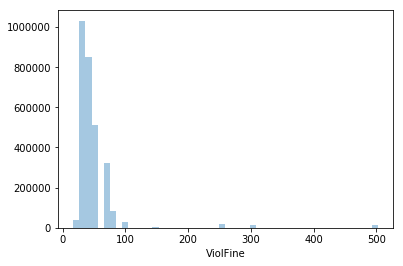

```python
print(sns.distplot(df['ViolFine'], kde=False))
```

#### Observations

It looks like most of the tickets issued are in the sub 100 area, with most being less than 50. This makes sense with fixed speed cameras being the most common violations, as their fines are 40. I am curious though as to what the fines > 300 are. What warrants a fine that high? Earlier when we did head and tail on the dataframe it looked like handicap violations were rather high, that could be it. Lets look at the uniqueness.

```python
print(df['Description'].loc[df['ViolFine'] > 300].unique())
print(df['Description'].loc[df['ViolFine'] > 300].count())
```

```
['No Stop/Park Handicap' 'Abandonded Vehicle'
 'Commercial Veh/Residence over 20,000 lbs'
 'No Parking/Standing Vendor Truck'
 'Unlawful Dumping/Waste Hauler w/o Permit']
25266
```

As I expected, Handicap fines are above 300. Also above 300 are commercial vehicle fines or fines that would only apply to people making money off their vehicles. Also Abandonded Vehicle is rather high, not sure what counts as abandonded and whether I agree with having such a high fine for just leaving your car somewhere.

There's also way too many for this to possibly be considered an outlier that we should trim off, especially since it would mean losing several types of fine.

### OpenFine

#### Description

OpenFine is the amount still remaining to be paid on the fine. I expect this to shift even more towards zero than the `ViolFine` distribution, since presumably people have paid off their fines. However, its distribution will be quite similar to `ViolFine` because the remaining tickets will be paid off.

#### Outliers

While we found a few extreme values in `ViolFine`, we chose not to do anything with them because there were enough to be meaningful and removing them would remove a large amount of ticket classes.

```
AxesSubplot(0.125,0.125;0.775x0.755)
['Abandonded Vehicle' 'No Stop/Park Handicap'
 'Commercial Veh/Residence over 20,000 lbs'
 'No Parking/Standing Vendor Truck'
 'Unlawful Dumping/Waste Hauler w/o Permit']
19276
```

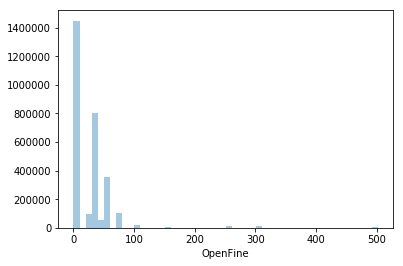

```python
print(sns.distplot(df['OpenFine'], kde=False))
print(df['Description'].loc[df['OpenFine'] > 300].unique())
print(df['Description'].loc[df['OpenFine'] > 300].count())
```

#### Observations

As predicted, there's a lot more `OpenFine`'s equal to zero because of people paying off the fines. Unfortunately it looks like many people don't pay off high value tickets. I wonder if that means they're fighting them in court or something else.

### OpenPenalty

#### Description

The `OpenPenalty` is the amount owed on a ticket that's overdue and has been asigned a penalty. I expect for a lot of tickets this will be zero.

#### Outliers

I expect for a lot of tickets this will be zero. There may also be some people with very high penalties who just never pay off their tickets.

```
AxesSubplot(0.125,0.125;0.775x0.755)
```

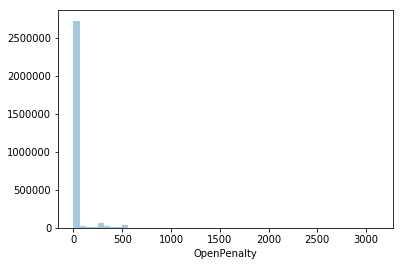

```python
print(sns.distplot(df['OpenPenalty'], kde=False))
```

Wow it looks like some people owe more than 1000 to the city. I checked to see what tickets people owe this much on and the results were pretty spread out. It might be worthwhile dropping outliers.

```python
print(df['Description'].loc[df['OpenPenalty'] > 1000].unique())
print(df['Description'].loc[df['OpenPenalty'] > 1000].count())
print(df['Description'].loc[df['OpenPenalty'] > 2000].unique())
print(df['Description'].loc[df['OpenPenalty'] > 2000].count())
```

```
['Expired Tags' 'No Stopping/Standing Tow Away Zone'
 'No Stop/Park Street Cleaning' 'All Other Parking Meter Violations'
 'Residential Parking Permit Only' 'No Stop/Park Handicap'
 'Commercial Veh/Residence under 20,000 lbs'
 'Obstruct/Impeding Flow of Traffic'
 'No Stopping//Parking Stadium Event Camden'
 'Commercial Vehicle Obstruct/Imped Traffic Flow'
 'Commercial Veh/Residence over 20,000 lbs'
 'All Other Stopping or Parking Violations'
 'No Stopping/Standing Not Tow-Away Zone'
 'Obstruct/Impeding Movement of Pedestrian'
 'No Parking/Standing In Transit Stop' 'Snow Emergency Route Violation'
 'Abandonded Vehicle' 'Obstructing/Imped Traffic Xwalk/inter/school'
 'Exceeding 48 Hours' 'Passenger Loading Zone'
 'Fire Lane/Handicapped Violation' 'Blocking Garage or Driveway'
 'Less Than 15 feet from Fire Hydrant']
849
['Expired Tags']
1
```

```python
df.drop(df[df['OpenPenalty'] > 2000].index, inplace=True)
```

```
AxesSubplot(0.125,0.125;0.775x0.755)
[]
0
```

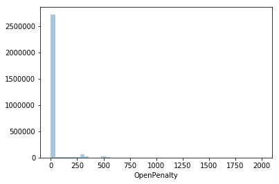

```python
print(sns.distplot(df['OpenPenalty'], kde=False))
print(df['Description'].loc[df['OpenPenalty'] > 2000].unique())
print(df['Description'].loc[df['OpenPenalty'] > 2000].count())
```

Since there was only one `OpenPenalty` greater than 2000 with a common violation type, I decided to drop it to make the data cleaner.

#### Observations

Overall the `OpenPenalty` column followed my prediction of there being lots of 0's and a few very high penalties.

### Balance

#### Description

This is the total ammount owed on a ticket. I will expect this one to also follow the same distribution as `OpenFine` and `OpenPenalty` in that many will be 0, a few will be reasonable and a handful will be very large.

#### Outliers

We previously eliminated the outliers so we don't need to do it for this one I don't think.

```
AxesSubplot(0.125,0.125;0.775x0.755)
```

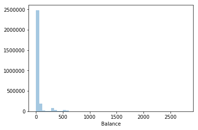

```python
print(sns.distplot(df['Balance'], kde=False))
```

#### Observations

This one met expectations in regards to the distribution. There are still a few very high, but it's minimal.

## Scatter Plots

In this section I do some scatter plotting to find correlation. The first thing I did however was use Pandas to create a correlation matrix to give me an idea of where I should look for correlation.

```python
corr = df.corr()
corr.style.background_gradient()
```

|  | Citation | ExpYY | ViolCode | ViolFine | Balance | PenaltyDate | OpenFine | OpenPenalty | CouncilDistrict |
| --- | --- | --- | --- | --- | --- | --- | --- | --- | --- |
| Citation | 1 | 0.0639186 | -0.0629567 | -0.119315 | -0.0649562 | nan | -0.145521 | -0.0327668 | 0.00460296 |
| ExpYY | 0.0639186 | 1 | -0.0189434 | 0.014887 | -0.108334 | nan | -0.11327 | -0.10362 | -0.0376296 |
| ViolCode | -0.0629567 | -0.0189434 | 1 | -0.0513461 | -0.0759456 | nan | -0.133117 | -0.0743919 | -0.0445935 |
| ViolFine | -0.119315 | 0.014887 | -0.0513461 | 1 | 0.206002 | nan | 0.675517 | 0.0448247 | -0.0128708 |
| Balance | -0.0649562 | -0.108334 | -0.0759456 | 0.206002 | 1 | nan | 0.359369 | 0.733723 | 0.0300504 |
| PenaltyDate | nan | nan | nan | nan | nan | nan | nan | nan | nan |
| OpenFine | -0.145521 | -0.11327 | -0.133117 | 0.675517 | 0.359369 | nan | 1 | 0.177173 | -0.000276839 |
| OpenPenalty | -0.0327668 | -0.10362 | -0.0743919 | 0.0448247 | 0.733723 | nan | 0.177173 | 1 | 0.0341287 |
| CouncilDistrict | 0.00460296 | -0.0376296 | -0.0445935 | -0.0128708 | 0.0300504 | nan | -0.000276839 | 0.0341287 | 1 |

### OpenPenalty -> Balance

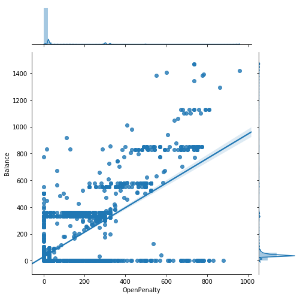

```python
sns.jointplot("OpenPenalty", "Balance", data=df[:50000], kind="reg", height=7)
```

### OpenFine -> OpenPenalty

I thought these two might be related earlier and the correlation grid confirmed my suspicions. The plot shows that there is a very small positive correlation between `OpenFine` and `OpenPenalty`. I assume this is because if someone gets a more expensive ticket, they are less likely to pay it immediately and therefore may get a penalty.

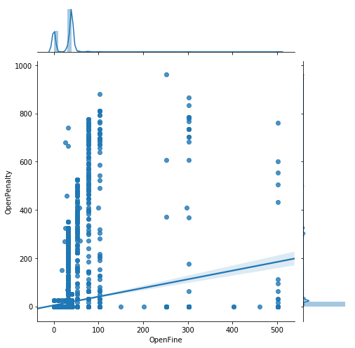

```python
sns.jointplot("OpenFine", "OpenPenalty", data=df[:50000], kind="reg", height=7)
```

## Predictor Plot

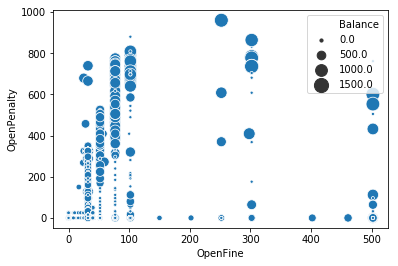

```python
sns.scatterplot(x="OpenFine", y="OpenPenalty", size="Balance", sizes=(10,200), data=df[:50000])
```